# Reproducible Research: Peer Assessment 1

## Loading and preprocessing the data

```r
unzip('activity.zip')
dataSet <- read.csv('activity.csv')
df <- dataSet[with(dataSet, !is.na({steps})), ]
```

## What is mean total number of steps taken per day?

- Calculate the total number of steps taken per day
- Make a histogram of the total number of steps taken each day
- Calculate and report the mean and median of the total number of steps taken per day

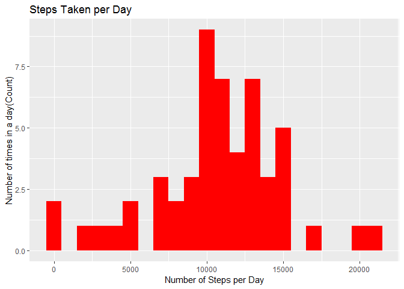

```r
steps_per_day <- aggregate(steps ~ date, df, sum)
colnames(steps_per_day) <- c("date","steps")
ggplot(steps_per_day, aes(x = steps)) +
       geom_histogram(fill = "red", binwidth = 1000) +
        labs(title="Steps Taken per Day",
             x = "Number of Steps per Day", y = "Number of times in a day(Count)")
```

```r
steps_day_mean <- mean(steps_per_day$steps)
steps_day_median <- median(steps_per_day$steps)
```

## What is the average daily activity pattern?

- Make a time series plot (i.e. type=“l”) of the 5-minute interval (x-axis) and the average number of steps taken, averaged across all days (y-axis)
- Which 5-minute interval, on average across all the days in the dataset, contains the maximum number of steps?

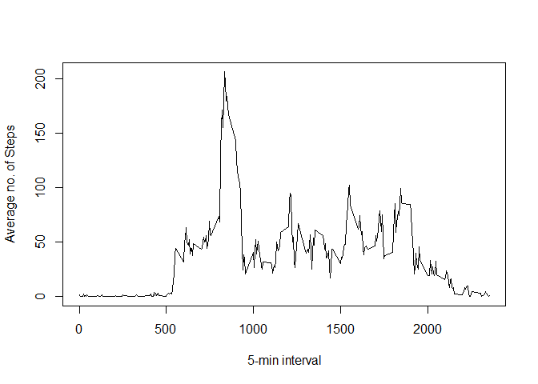

```r
avg <- tapply(dataSet$steps, dataSet$interval, mean, na.rm=TRUE)
plot(names(avg), avg, xlab="5-min interval", type="l", ylab="Average no. of Steps")
```

```r
maxavg <- max(avg)
maxinterval <- as.numeric(names(avg)[which(avg==max(avg))])
```

- Max Avg. Value 206.1698113
- Interval 5-min 835

## Imputing missing values

Note that there are a number of days/intervals where there are missing values (coded as NA). The presence of missing days may introduce bias into some calculations or summaries of the data.

- Calculate and report the total number of missing values in the dataset (i.e. the total number of rows with NA|NAs)

```r
totalNAs <- sum(is.na(dataSet$steps))
```

Total NAs: 2304

- Devise a strategy for filling in all of the missing values in the dataset. The strategy does not need to be sophisticated. For example, you could use the mean/median for that day, or the mean for that 5-minute interval, etc.

```r
# creating a copy of data set so that the missing value can be imputed in it
imputedata <- dataSet

# Devise a strategy for filling in all of the missing values in the dataset.
# In place of NA, using the mean for that 5-minute interval.
imputedata$steps[which(is.na(dataSet$steps))]<- as.vector(avg[as.character(dataSet[which(is.na(dataSet$steps)),3])])
```

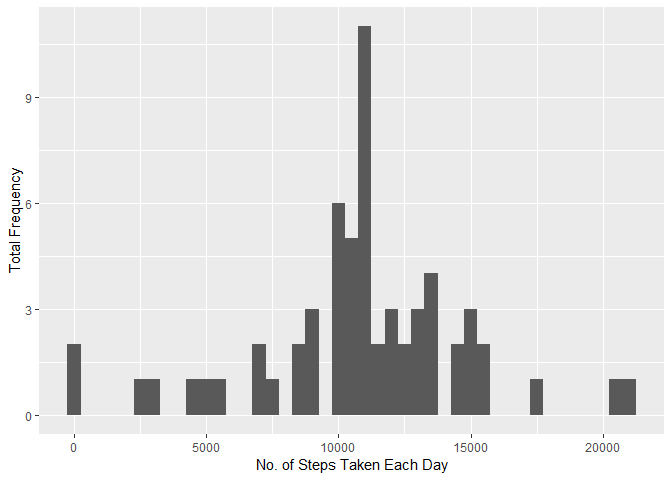

```r
stepseachday <- tapply(imputedata$steps, imputedata$date, sum, na.rm=TRUE)
qplot(stepseachday, xlab="No. of Steps Taken Each Day", ylab="Total Frequency", binwidth=500)
```

```r
mean_each_day_imputed <- mean(stepseachday)
median_each_day_imputed <- median(stepseachday)
```

## Are there differences in activity patterns between weekdays and weekends?

For this part the weekdays() function may be of some help here. Use the dataset with the filled-in missing values for this part.

- Create a new factor variable in the dataset with two levels - “weekday” and “weekend” indicating whether a given date is a weekday or weekend day.

```r
imputedata$dayType<- ifelse(as.POSIXlt(imputedata$date)$wday %in% c(0,6), "weekends","weekdays")
```

*Make a panel plot containing a time series plot (i.e. type=“l”) of the 5-minute interval (x-axis) and the average number of steps taken, averaged across all weekday days or weekend days (y-axis).

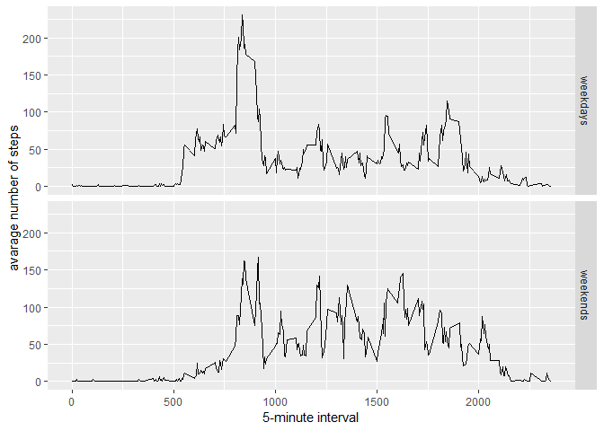

```r
aggregateData<- aggregate(steps ~ interval + dayType, data=imputedata, mean)
ggplot(aggregateData, aes(interval, steps)) +
    geom_line() +
    facet_grid(dayType ~ .) +
    xlab("5-minute interval") +
    ylab("avarage number of steps")
```